# Optimization

- Course: BUDT758X
- Instructor: Prof. Sean Barnes
- Student: Xukun(Frank) LIU (https://www.xukun-liu.com/)
- Topics: #Optimization #scipy

Today, we will cover optimization modeling in Python, using the scipy.optimize package.

```python
%pylab inline
import scipy.optimize as so
import pandas as pd
```

## Review of Optimization Modeling

Optimization is the process of finding the best solution to a problem, given a limited set of options. Solving an optimization typically involves three distinct steps:

- Formulating the optimization problem - Define decision variables and specify objective function and constraints, expressed as a function of the decision variables, fixed input parameters, and any intermediate calculations
- Solving the optimization problem - Identify and employ an appropriate algorithm to identify the best set of decision variables, given the objective function and the constraints
- Performing sensitivity analysis - Explore relevant alternative scenarios and understand the impact on the optimal decision variables and objective function

## Island Sunglasses

Recap: Goal is to determine optimal price for new product.

**Demand**: $Q = M(1 - \frac{P}{U})$

where:

- Q: Quantity demanded
- P: Price
- M: Maximum market size (Q when P = 0) = 10,000
- U: Maximum price (generates Q = 0) = \$50

**Cost** = F + VQ

where:

- F: Fixed production cost = \$50,000
- V: Variable production cost = \$10/unit

**Formulation**

Fixed input parameters: Maximum market size (M), maximum price (U), fixed production cost (F), variable production cost (V)

Decision variable: Price (P)

Intermediate calculations:

- Demand: $Q = M(1 - \frac{P}{U})$
- Revenue: $PQ$
- Cost: $F + VQ$

Objective function: $max$ Profit = Revenue - Cost

Constraints:

- Maximum price: $P \le U$
- Non-negativity: $P \ge 0$

### Solution Procedures

```python
# Define fixed input parameters
M = 10000
U = 50
F = 50000
V = 10
```

#### Brute Force Approach

Given that we only have a single decision variable, and this variable is contained in a fairly small interval (i.e., $P \in [0, U]$), we can vary the price throughout this range and determine the value that produces the optimal objective function value (i.e., maximum profit).

```python
# Create array of trial price values
P = np.arange(0, U + 0.01, 0.01)
P[:10]
```

```
array([0.  , 0.01, 0.02, 0.03, 0.04, 0.05, 0.06, 0.07, 0.08, 0.09])
```

```python
# Perform intermediate calculations
Q = M * (1 - P / U)
revenue = P * Q
cost = F + V * Q
```

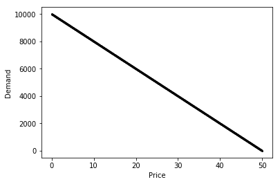

```python
# Visualize demand as a function of price
plt.plot(P, Q, 'k.', markersize=2)
plt.xlabel('Price')
plt.ylabel('Demand');
```

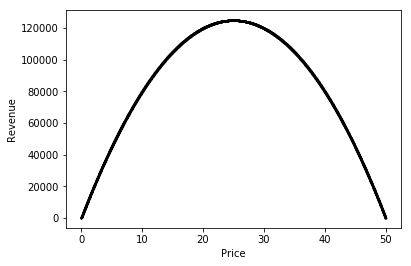

```python
# Visualize revenue as a function of price
plt.plot(P, revenue, 'k.', markersize=2)
plt.xlabel('Price')
plt.ylabel('Revenue');
```

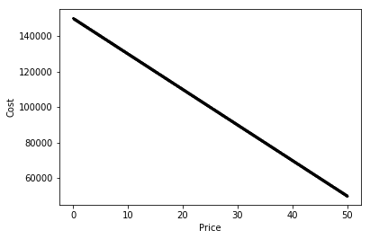

```python
# Visualize cost as a function of price
plt.plot(P, cost, 'k.', markersize=2)
plt.xlabel('Price')
plt.ylabel('Cost');
```

```python
# Calculate profit objective function
profit = revenue - cost
```

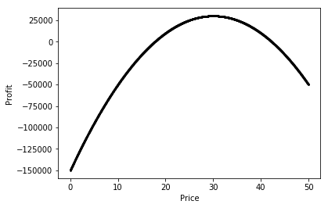

```python
# Visualize profit as a function of cost
plt.plot(P, profit, 'k.', markersize=2)
plt.xlabel('Price')
plt.ylabel('Profit');
```

```python
# Determine optimal price and profit
iopt = profit.argmax()
Popt = P[iopt]
profit_opt = profit[iopt]
print('The optimal price is $%.2f' % Popt)
print('The optimal profit is $%.2f' % profit_opt)
```

```
The optimal price is $30.00
The optimal profit is $30000.00
```

#### Function Minimization Approach

The scipy.optimize package offers an entire library of optimization solvers, including the **fminbound** function that can be used to solve a *minimization* problem involving a single decision variable. The function accepts the following (primary) arguments:

- *fun* - A function object that calculates the (scalar) objective function value. The function should accept the decision variable (x) as its first argument, but it may accept other arguments as well (see *args* below). Note that for maximization problems, the function should return the negated objective function value (i.e., a maximization objective is equivalent to minimizinig the negative objective function).
- *x1, x2* - Floats that defines the search bounds (x1 - min, x2 - max) for the decision variable.
- *args* - A sequence of additional arguments to pass to the objective function object.

The function returns the optimal decision variable value (xopt).

For additional details, please see https://docs.scipy.org/doc/scipy/reference/generated/scipy.optimize.fminbound.html#scipy.optimize.fminbound.

```python
# Define objective function
def profit(x, M=10000, U=50, F=50000, V=10):
    # Perform intermediate calculations
    Q = M * (1 - x / U)
    revenue = x * Q
    cost = F + V * Q

    # Return profit
    return -(revenue - cost)
```

```python
# Solve optimization problem
Popt = so.fminbound(profit, x1=0, x2=U, args=())
```

```python
# Output results
print('The optimal price is $%.2f' % Popt)
print('The optimal profit is $%.2f' % -profit(Popt))
```

```
The optimal price is $30.00
The optimal profit is $30000.00
```

### Sensitivity Analysis

```python
# One-way sensitivity analysis
param = 'U'
vals = np.arange(50,110,10)
Popts = []
for val in vals:
    exec(param + ' = ' + str(val))
    Popt = so.fminbound(profit, x1=0, x2=U, args=(M, U, F, V))
    Popts.append(Popt)
Popts = np.array(Popts)
```

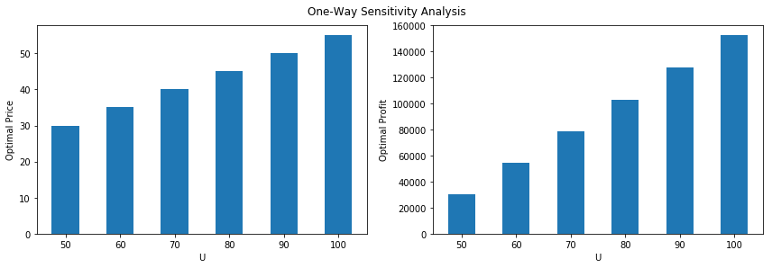

```python
# Visualize results
plt.figure(figsize=(12,4))
plt.subplot(1,2,1)
plt.bar(vals, Popts, width=5)
plt.xlabel(param)
plt.ylabel('Optimal Price')

plt.subplot(1,2,2)
plt.bar(vals, eval('-profit(Popts, ' + param + '=vals)'), width=5)
plt.xlabel(param)
plt.ylabel('Optimal Profit')

plt.suptitle('One-Way Sensitivity Analysis', y=1.025)

plt.tight_layout()
```

## Giant Motor Company

The Giant Motor Company has just opened two new manufacturing plants to produce its Lyra, Libra, and Hydra models, which have respective total demands of 1.4, 1.1, and 0.8 million units.

Plant 1 has a capacity to produce up to 1.5 million cars (of any type), while Plant 2 can produce up to 1.8 million cars (of any type).

Due to variation in cost efficiencies at the respective plants, the profit margins per unit sold (in thousands) depend on the plant where the vehicle was produced, noting that Plant 1 does not have the ability to produce the Hydra model:

```python
df = pd.DataFrame({'Plant 1': [2.5, 3, np.nan], 'Plant 2': [2.3, 3.5, 4.8]}, index=['Lyra', 'Libra', 'Hydra'])
df
```

|  | Plant 1 | Plant 2 |
| --- | --- | --- |
| Lyra | 2.5 | 2.3 |
| Libra | 3.0 | 3.5 |
| Hydra | NaN | 4.8 |

**Formulation**

Fixed input parameters:

- Demands of 1.4, 1.1, and 0.8 million units for the Lyra, Libra, and Hydra models, respectively
- Plant capacities of 1.5 and 1.8 million units for Plant 1 and Plant 2, respectively
- Plant-based per-unit profit margines, reported above

Decision variables: Let $Lyra_1$, $Lyra_2$, $Libra_1$, $Libra_2$, and $Hydra_2$ serve as decision variables that represent the number of respective models to be produced (in millions) at Plant 1 and Plant 2, respectively

Objective Function:

$max$ Profit (in billions) = $2.5 * Lyra_1 + 2.3 * Lyra_2 + 3 * Libra_1 + 3.5 * Libra_2 + 4.8 * Hydra_2$

Constraints:

Demand Limits (excess production has no benefit with respect to objective function)

1. $Lyra_1 + Lyra_2 \le 1.4$
2. $Libra_1 + Libra_2 \le 1.1$
3. $Hydra_2 \le 0.8$

Supply Limits

1. $Lyra_1 + Libra_1 \le 1.5$
2. $Lyra_2 + Libra_2 + Hydra_2 \le 1.8$

Non-negativity

1. $Lyra_1, Lyra_2, Libra_1, Libra_2, Hydra_2 \ge 0$

### Solution Procedure

In this case, given that we have 5 decision variables that can take on a broad range of values (e.g., from 0 up to the maximum demand for each model type), a brute-force approach would not be efficient. Therefore, we need an algorithm that supports solving the problem more directly.

The scipy.optimize package offers the **linprog** function that can be used to solve linear optimization problems with one or more decision variables. The linprog function requires that the formulation be expressed in linear algebraic form:

$min \quad c^T * x$

subject to:

$A_{ub} * x \le b_{ub}$

$A_{eq} * x = b_{eq}$

Therefore, the arguments to the linprog function are:

- *c* - A 1-dimensional array of objective function coefficients
- $A_{ub}$ - A 2-dimensional array of decision variable coefficients for each upper-bound constraint (i.e., $\le$)
- $b_{ub}$ - A 1-dimensional array of right-hand side constants for each upper-bound constraint
- $A_{eq}$ - A 2-dimensional array of decision variable coefficients for each equality constraint (i.e., $=$)
- $b_{eq}$ - A 1-dimensional array of right-hand side constants for each equality constraint
- *bounds* - An (optional) sequence of (lower, upper) bounds for each decision variable. Note that these bounds can also be enforced via the upper-bound constraints (e.g., $-x \le 0$ and $x \le 10$).

The function returns an OptimizeResults object, for which we can extract the optimal solution and optimal objective function value via the .x and .fun attributes, respectively.

```python
# Define decision variable names
dvars = ['Lyra1','Lyra2','Libra1','Libra2','Hydra2']
```

```python
# Define objective function coefficients - Note the negative sign since this is a maximization
c = -np.array([2.5, 2.3, 3., 3.5, 4.8])
```

```python
# Define upper-bound constraint arrays -
# Total demand for Lyra and Libra and capacity constraints for Plant 1 and Plant 2
Aub = np.array([[1, 1, 0, 0, 0],
                [0, 0, 1, 1, 0],
                [1, 0, 1, 0, 0],
                [0, 1, 0, 1, 1]])

bub = np.array([1.4, 1.1, 1.5, 1.8])
```

```python
# Define bounds - Enforce non-negativity and maximum model production
bounds = [(0, 1.4), (0, 1.4), (0, 1.1), (0, 1.1), (0, 0.8)]
```

```python
# Solve optimization problem
res = so.linprog(c=c, A_ub=Aub, b_ub=bub, bounds=bounds)
```

```python
# Optimal solution
pd.Series(res.x, index=dvars)
```

```
Lyra1     1.4
Lyra2     0.0
Libra1    0.1
Libra2    1.0
Hydra2    0.8
dtype: float64
```

```python
# Optimal objective function value
print('The optimal profit is $%.2fB' % -res.fun)
```

```
The optimal profit is $11.14B
```

```python
# Check constraints
pd.DataFrame({'LHS': Aub.dot(res.x), 'RHS': bub}, index=['Lyra Demand', 'Libra Demand', 'Plant 1 Supply', 'Plant 2 Supply'])
```

|  | LHS | RHS |
| --- | --- | --- |
| Lyra Demand | 1.4 | 1.4 |
| Libra Demand | 1.1 | 1.1 |
| Plant 1 Supply | 1.5 | 1.5 |
| Plant 2 Supply | 1.8 | 1.8 |

```python
# Check bounds
pd.DataFrame({'Lower Bound': [tup[0] for tup in bounds], 'Value': res.x, 'Upper Bound': [tup[1] for tup in bounds]},
            columns=['Lower Bound', 'Value', 'Upper Bound'], index=dvars)
```

|  | Lower Bound | Value | Upper Bound |
| --- | --- | --- | --- |
| Lyra1 | 0 | 1.4 | 1.4 |
| Lyra2 | 0 | 0.0 | 1.4 |
| Libra1 | 0 | 0.1 | 1.1 |
| Libra2 | 0 | 1.0 | 1.1 |
| Hydra2 | 0 | 0.8 | 0.8 |

### Sensitivity Analysis

The Giant Motor Company is considering increasing the capacity of one of its manufacturing facilities. Which facility would be most beneficial for the company to increase its capacity for producing vehicles, and how much of an increase in capacity should the company consider?

```python
# Plant 1
capacities = np.arange(1.5, 2.6, 0.1)
bub_sa = bub.copy()
rdf = pd.DataFrame()
profits = []
for cap in capacities:
    bub_sa[2] = cap
    res = so.linprog(c=c, A_ub=Aub, b_ub=bub_sa, bounds=bounds)
    rdf[cap] = pd.Series(res.x, index=dvars)
    profits.append(-res.fun)
rdf.loc['Profit'] = profits
rdf.columns = np.round(rdf.columns, 1)
rdf.columns.name = 'Plant 1 Capacity'
rdf
```

| Plant 1 Capacity | 1.5 | 1.6 | 1.7 | 1.8 | 1.9 | 2.0 | 2.1 | 2.2 | 2.3 | 2.4 | 2.5 |
| --- | --- | --- | --- | --- | --- | --- | --- | --- | --- | --- | --- |
| Lyra1 | 1.40 | 1.40 | 1.40 | 1.40 | 1.40 | 1.40 | 1.40 | 1.40 | 1.40 | 1.40 | 1.40 |
| Lyra2 | 0.00 | 0.00 | 0.00 | 0.00 | 0.00 | 0.00 | 0.00 | 0.00 | 0.00 | 0.00 | 0.00 |
| Libra1 | 0.10 | 0.10 | 0.10 | 0.10 | 0.10 | 0.10 | 0.10 | 0.10 | 0.10 | 0.10 | 0.10 |
| Libra2 | 1.00 | 1.00 | 1.00 | 1.00 | 1.00 | 1.00 | 1.00 | 1.00 | 1.00 | 1.00 | 1.00 |
| Hydra2 | 0.80 | 0.80 | 0.80 | 0.80 | 0.80 | 0.80 | 0.80 | 0.80 | 0.80 | 0.80 | 0.80 |
| Profit | 11.14 | 11.14 | 11.14 | 11.14 | 11.14 | 11.14 | 11.14 | 11.14 | 11.14 | 11.14 | 11.14 |

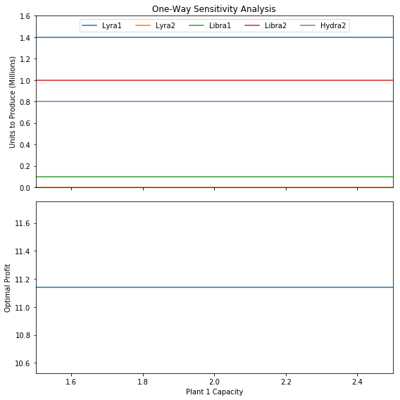

```python
# Visualize results
fig, ax = plt.subplots(2, 1, sharex=True, figsize=(8,8))

rdf.loc['Lyra1':'Hydra2'].T.plot(kind='line', ax=ax[0], title='One-Way Sensitivity Analysis')
ax[0].set_ylim([0,1.6])
ax[0].set_ylabel('Units to Produce (Millions)')
ax[0].legend(loc='upper center', ncol=5)

rdf.loc['Profit'].T.plot(kind='line', legend=False, ax=ax[1])
ax[1].set_ylabel('Optimal Profit')

fig.tight_layout();
```

```python
# Plant 2
capacities = np.arange(1.8, 3.4, 0.1)
bub_sa = bub.copy()
rdf = pd.DataFrame()
profits = []
for cap in capacities:
    bub_sa[3] = cap
    res = so.linprog(c=c, A_ub=Aub, b_ub=bub_sa, bounds=bounds)
    rdf[cap] = pd.Series(res.x, index=['Lyra1','Lyra2','Libra1','Libra2','Hydra2'])
    profits.append(-res.fun)
rdf.loc['Profit'] = profits
rdf.columns = np.round(rdf.columns, 1)
rdf.columns.name = 'Plant 2 Capacity'
rdf
```

| Plant 2 Capacity | 1.8 | 1.9 | 2.0 | 2.1 | 2.2 | 2.3 | 2.4 | 2.5 | 2.6 | 2.7 | 2.8 | 2.9 | 3.0 | 3.1 | 3.2 | 3.3 |
| --- | --- | --- | --- | --- | --- | --- | --- | --- | --- | --- | --- | --- | --- | --- | --- | --- |
| Lyra1 | 1.40 | 1.40 | 1.40 | 1.40 | 1.40 | 1.40 | 1.40 | 1.40 | 1.40 | 1.40 | 1.40 | 1.40 | 1.40 | 1.40 | 1.40 | 1.40 |
| Lyra2 | 0.00 | 0.00 | 0.00 | 0.00 | 0.00 | 0.00 | 0.00 | 0.00 | 0.00 | 0.00 | 0.00 | 0.00 | 0.00 | 0.00 | 0.00 | 0.00 |
| Libra1 | 0.10 | 0.00 | 0.00 | 0.00 | 0.00 | 0.00 | 0.00 | 0.00 | 0.00 | 0.00 | 0.00 | 0.00 | 0.00 | 0.00 | 0.00 | 0.00 |
| Libra2 | 1.00 | 1.10 | 1.10 | 1.10 | 1.10 | 1.10 | 1.10 | 1.10 | 1.10 | 1.10 | 1.10 | 1.10 | 1.10 | 1.10 | 1.10 | 1.10 |
| Hydra2 | 0.80 | 0.80 | 0.80 | 0.80 | 0.80 | 0.80 | 0.80 | 0.80 | 0.80 | 0.80 | 0.80 | 0.80 | 0.80 | 0.80 | 0.80 | 0.80 |
| Profit | 11.14 | 11.19 | 11.19 | 11.19 | 11.19 | 11.19 | 11.19 | 11.19 | 11.19 | 11.19 | 11.19 | 11.19 | 11.19 | 11.19 | 11.19 | 11.19 |

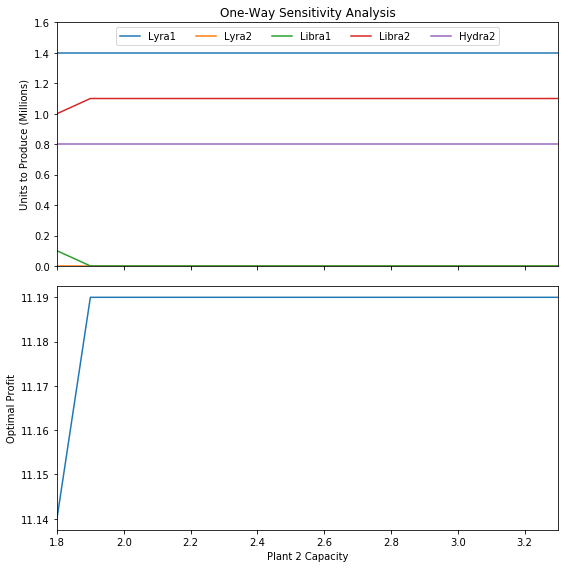

```python
# Visualize results
fig, ax = plt.subplots(2, 1, sharex=True, figsize=(8,8))

rdf.loc['Lyra1':'Hydra2'].T.plot(kind='line', ax=ax[0], title='One-Way Sensitivity Analysis')
ax[0].set_ylim([0,1.6])
ax[0].set_ylabel('Units to Produce (Millions)')
ax[0].legend(loc='upper center', ncol=5)

rdf.loc['Profit'].T.plot(kind='line', legend=False, ax=ax[1])
ax[1].set_ylabel('Optimal Profit')

fig.tight_layout();
```

In conclusion, it would not help The Giant Motor Company to increase the production capacity of Plant 1, as the production schedule and optimal profit would remain the same. However, if The Giant Motor Company were to increase the production capacity of Plant 2 by 100,000 units (i.e., to 1.9M units), it could fulfill all of the Libra demand from Plant 2, where producing the model is more profitable. The additional 100,000 units produced at Plant 2 would earn an additional \$500 of profit per unit = \\$50M, leading to total profits of \$11.19B. Therefore, the shadow price of an additional unit of production capacity at Plant 2 is equal to \\$500. In other words, The Giant Motor Company would be willing to pay up to \$500 for each additional unit of production capacity at Plant 2, for up to 100,000 additional units. Beyond that point, there would be no additional benefit.

# Next Time: Simulation and Statistical Inference